# Ordinal Logistic Regression in R

Clay Ford, UVA Library

```r
# trees is a data set that comes with R
pairs(trees)
```

[output not shown]

To hide the output, click the Expand/Collapse output button. To clear results (or an error), click the “x”.

You can also press *Ctrl+Enter* (Win/Linux) or *Cmd+Return* (Mac) to run one line of code at a time (instead of the entire chunk).

Add a new R code chunk by clicking the *Insert Chunk* button on the toolbar or by pressing *Ctrl+Alt+I* (Win/Linux) or *Cmd+Option+I* (Mac).

## CODE ALONG 0

Try the `cumsum()` function with the vector `1:5`

```r
cumsum(1:5)
```

## Load Packages

We’ll use the following packages in today’s workshop.

```r
library(vcd)
library(MASS)
library(car)
library(effects)
```

## Review: Probabilities and Cumulative Probabilities

Let’s say I randomly sample 100 UVA students and ask them to rate how spicy they like their food on a scale of 1 - 5, where 1 is no spice and 5 is maximum spiciness. Below are the (made up) responses entered manually using a named vector.

```r
resp <- c("none" = 17,
          "mild" = 23,
          "medium" = 31,
          "hot" = 21,
          "maximum" = 8)
resp
```

I can calculate proportions from this data and use these as estimates of *probabilities*. Using the `proportions()` function on a vector of numbers returns the proportion of each value relative to the total of the vector.

```r
proportions(resp)
```

Based on this random sample I might estimate that a randomly selected UVA student has a probability of about 0.31 of liking medium spicy food. I’m using my observed proportion as an estimate of probability.

Another way to summarize the results is with *cumulative probabilities*. For example, what’s the the probability a randomly selected student can handle *medium heat or less*? Using the `cumsum()` we can calculate cumulative sums of proportions and answer this question. Below we take the proportions and “pipe” into the `cumsum()` function using the base R pipe operator.

```r
proportions(resp) |> cumsum()
```

```
   none    mild  medium     hot maximum
   0.17    0.40    0.71    0.92    1.00
```

Based on this calculation I might estimate that a randomly selected student has a probability of about 0.71 of liking *medium or lower* spiciness. We might state this mathematically as follows:

$$P[X \le \text{medium}] = 0.71$$

In this case we’re using the *ordering of the responses* to make additional inferences about student spiciness preference.

What if we also collected additional information such as the sex of the respondents? Does being male or female affect the *cumulative probability* of 0.71? Do we expect that to be higher for one sex?

What about age or weight? Does being older and heavier affect the *cumulative probability* of spiciness preference?

*Ordinal Logistic Regression* is a method that allows us to investigate questions such as this. It allows us to *model the cumulative probability* of an ordered category given multiple predictors.

Performing Ordinal Logistic Regression is like fitting any other statistical model. We have to…

1. propose and fit a model
2. assess if the model is good
3. use the model to make predictions and/or quantify relationships

## Load Data for the workshop

Today we’ll work with data from a double-blind clinical trial investigating a new treatment for rheumatoid arthritis (Koch & Edwards, 1988). The data is available in the vcd package (Meyer et al, 2022)

```r
data("Arthritis", package = "vcd")
```

If for some reason you can’t install the vcd package, you can also download the data from GitHub:

```r
URL <- "https://github.com/clayford/OLR_in_R/raw/main/data/arthritis.rds"
Arthritis <- readRDS(file = url(URL))
```

The goal today is to teach the basics of Ordinal Logistic Regression by developing a model to predict the *cumulative probability* of pain improvement after treatment adjusting for age and sex.

### List of variables

```r
names(Arthritis)
```

```
[1] "ID"        "Treatment" "Sex"       "Age"       "Improved"
```

- ID: patient ID
- Treatment: factor indicating treatment (Placebo, Treated).
- Sex: factor indicating sex (Female, Male).
- Age: age of patient in years
- Improved: *ordered factor* indicating treatment outcome (None, Some, Marked).

## Ordered Factors

An ordered factor is a *categorical variable with ordered levels*. Examples of ordered categorical variables include:

- Satisfaction/Recommendation ratings (Poor, Fair, Good, Excellent)
- Pain scales (none, mild, moderate, severe)
- Experience (none, some, proficient, expert)
- Likert scale ratings (disagree, neutral, agree; OR never, sometimes, always)

We can format a categorical variable as an ordered factor using the `factor()` function with the argument `ordered = TRUE`. *Note we are responsible for creating the order!* Otherwise R will set the order alphabetically.

Quick example using fake data. Sample from a vector 50 times with replacement using the `sample()` function.

```r
experience <- sample(c("none", "some", "proficient", "expert"),
                     size = 50, replace = TRUE)
head(experience)
```

```
[1] "some"       "proficient" "expert"     "expert"     "some"
[6] "proficient"
```

Let’s convert to factor. Notice there is no ordering of the levels. They are simply listed alphabetically.

```r
experience <- factor(experience)
head(experience)
```

```
[1] some       proficient expert     expert     some       proficient
Levels: expert none proficient some
```

Now convert to *ordered factor*. Notice the levels are ordered but still in alphabetical order. The notation `expert < none < proficient < some` says “expert” is less than “none”, which is less than “proficient”, which is less than “some”. According to this ordering “some” is the highest, which doesn’t make sense.

```r
experience <- factor(experience, ordered = TRUE)
head(experience)
```

```
[1] some       proficient expert     expert     some       proficient
Levels: expert < none < proficient < some
```

Now let’s set the appropriate ordering of the levels using the `levels` argument.

```r
experience <- factor(experience, ordered = TRUE,
                     levels = c("none", "some", "proficient", "expert"))
head(experience)
```

```
[1] some       proficient expert     expert     some       proficient
Levels: none < some < proficient < expert
```

This is an important data wrangling step when preparing for Ordinal Logistic Regression.

## Explore the Arthritis data

Our response is the Improved variable. Let’s tabulate the counts using `xtabs()`. The notation `~ Improved` means “tabulate by Improved”.

```r
xtabs(~ Improved, data = Arthritis)
```

```
Improved
  None   Some Marked
    42     14     28
```

How does Improved breakdown between the Treatments? The notation `~ Treatment + Improved` means “tabulate by Treatment and Improved, with Treatment in the rows and Improved in the columns.”

```r
xtabs(~ Treatment + Improved, data = Arthritis)
```

```
         Improved
Treatment None Some Marked
  Placebo   29    7      7
  Treated   13    7     21
```

Now stratify by Sex. We have some sparse cells in the Male table.

```r
xtabs(~ Treatment + Improved + Sex, data = Arthritis)
```

```
, , Sex = Female

         Improved
Treatment None Some Marked
  Placebo   19    7      6
  Treated    6    5     16

, , Sex = Male

         Improved
Treatment None Some Marked
  Placebo   10    0      1
  Treated    7    2      5
```

Finally let’s look at how Age relates to Improved using a spine plot. It appears older subjects are somewhat more likely to see some improvement, at least for ages 35 - 60.

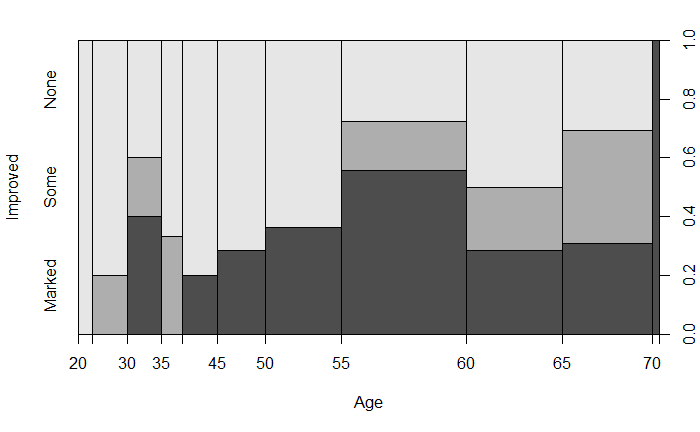

```r
plot(Improved ~ Age, data = Arthritis)
```